# TritonX-epistasis analysis

### 4.Quantify epistatic interactions

#### a. Normalize data:

> in this set, all assays only have AM373 and CssS in common

- because of CM/CN data, no longer have all strains in all assays
- now will normalize by average of strains that are in all measurements - A & C

#### b. Mean and sd of each assay level:

**average value of all replicates of each assay & strain:**

```
##             assay media num AM373  CssS  McpA  NhaK    CM    CN    MN
## 1   lambda.spline TritX  19 1.039 0.961 0.985 0.990 0.906 0.930 1.019
## 2    ln_mu.spline TritX  19 0.980 1.020 1.003 0.987 1.042 1.020 0.954
## 3        A.spline TritX  19 1.004 0.996 1.006 1.003 0.974 0.974 1.002
## 4 integral.spline TritX  19 1.003 0.997 1.035 1.023 0.993 0.974 1.003
```

**table of percent differences of each mutant strain from AM373:**

```
##             assay media num   CssS   McpA   NhaK     CM     CN     MN avg_sd
## 1   lambda.spline TritX  19 -0.075 -0.052 -0.047 -0.128 -0.105 -0.019  0.046
## 2    ln_mu.spline TritX  19  0.041  0.023  0.007  0.063  0.041 -0.027  0.043
## 3        A.spline TritX  19 -0.008  0.002 -0.001 -0.030 -0.030 -0.002  0.014
## 4 integral.spline TritX  19 -0.006  0.032  0.020 -0.010 -0.029  0.000  0.042
```

**table of st. dev. associated with each value in above table:**

```
##             assay media num  CssS  McpA  NhaK    CM    CN    MN
## 1   lambda.spline TritX  19 0.029 0.052 0.073 0.035 0.052 0.033
## 2    ln_mu.spline TritX  19 0.018 0.054 0.045 0.046 0.042 0.054
## 3        A.spline TritX  19 0.007 0.018 0.013 0.017 0.021 0.007
## 4 integral.spline TritX  19 0.037 0.052 0.070 0.031 0.037 0.027
```

#### Plots of normalized data:

- Noramlized by (x-avgAM373)/avgAM373

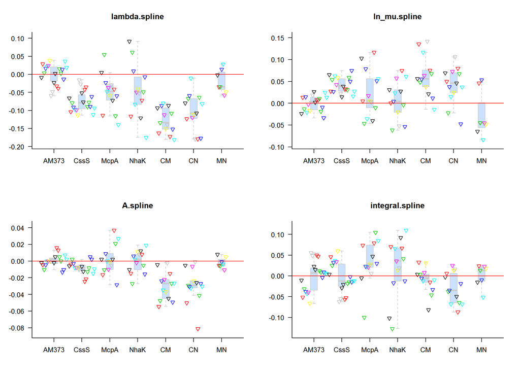

#### c. Calculate estimated value of double mutants from the single mutants, and whether the measure phenotypes of the double mutants are sig dif from that estimate

1. normalize each assay by the AM373 measurement (x-AM373)/AM373
2. estimate double-mutant value by adding effect size of single mutants
3. perform t.test and wilcoxon rank sum test to compare measured and estimated values, estimate if sig dif
- using paired=TRUE
- also, plots include all data, while epistasis calculations only include complete cases - so AM373 & CssS plots show datapoints not included in calculation